# Reflections on Modelling Movement Potential using Least Cost Paths

Joseph Lewis

28/05/2020

## Why Model Movement and Mobility in Archaeology using Least Cost Paths?

We learn and structure the world through mobility within it (Bender 2001; Leary 2014; Sheets-Johnstone 2011). Mobility affects how we become part of the political and social structure of society (Beaudry and Parno 2013; Ingold 2004; Lelièvre and Marshall 2015), as well as establish and maintain the social linkages between individual, groups, and political units (Lelièvre and Marshall 2015; Tilley 1994).

## What is the difference between mobility and movement? and why does it matter when modelling?

Following Close (2000), I define **mobility** as the **ability to move**, whereas **movement** is **how far, in what direction, how often, and why people moved**. When applying Least Cost Path analysis to archaeological problems, we alternate between the concepts of mobility and movement, often unknowingly.

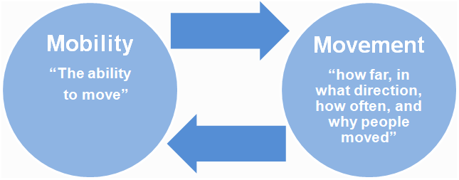

**Cost surfaces** (left), which numerically express the difficulty of moving between individuals cells in a landscape, is a **representation of mobility**, whereas **Least Cost Paths** (right) are concerned with **movement** between locations and focus on the distance and speed of this movement.

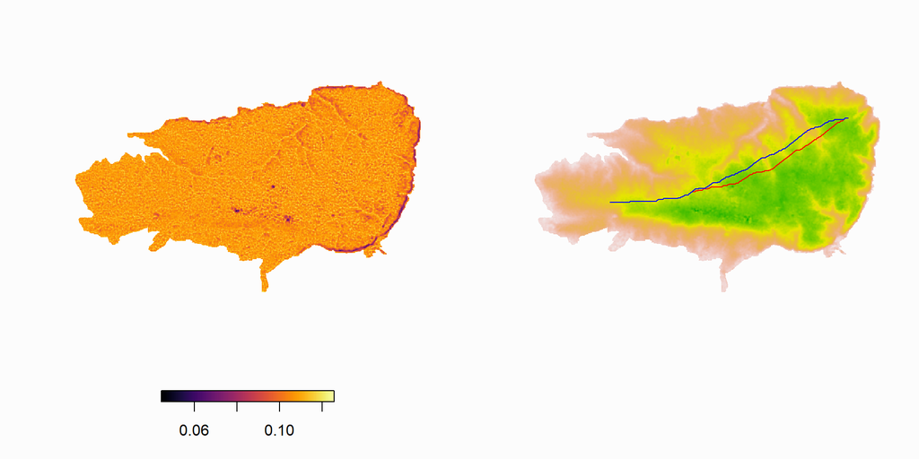

Slope-based Cost Surface (left) and Elevation Data with Least Cost Paths from Two Locations in Landscape (right)

The distinction between mobility and movement becomes less clear when discussing least cost path derivations such as ‘From Everywhere To Everywhere’ (FETE) (White and Barber 2012). By calculating Least Cost Paths between multiple locations in a landscape, areas of preferential movement can be identified. Through this, we alternate from assessing the concept of movement, in which we are interested in understanding how far and which direction movement occured, to the concept of mobility, where the ability of movement is of interest. Although moving between concepts may not appear to be an issue, we must verify whether the assumptions made when first alternating from mobility to movement are still valid when moving back.

In this reflection, **I argue that we cannot alternate between the concepts of mobility and movement without acknowledging that they represent different things, are not interchangeable, and that the assumptions made must be valid when applied to both concepts.**

### Consider the following:

1. We are interested in modelling mobility of prehistoric people within a landscape. We explicitly assume that slope is the only factor that influenced movement. We also assume that movement occured within *wide corridors* as opposed to a single route.
2. In order to assess mobility within the landscape, we must first alternate between the concept of mobility and movement. To do this, we use the From Everywhere to Everywhere method (White and Barber 2012) and compute Least Cost Paths between multiple locations within the landscape (left). From this, we create a surface that identifies routes of preferential movement (right).

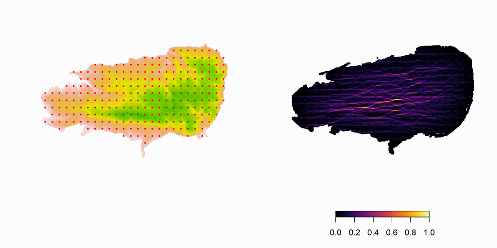

Elevation Data with Locations within landscape (left) and From Everywhere to Everywhere Surface (right)

3. The resultant surface now represents mobility within the landscape. By computing Least Cost Paths between multiple locations when creating the surface, we assumed that movement from each location occured along a single route (i.e. the least costly route). Does this assumption agree with all of our initial assumptions? Hopefully your response was **NO!** Initially, we assumed that movement occured within wide corridors, and yet through alternating between the concepts of mobility and movement our assumption updated to where movement now occured along a single route *(technically multiple single routes…)*

### Instead, consider:

1. We are interested in modelling mobility of prehistoric people within a landscape. We explicitly assume that slope is the only factor that influenced movement. We also assume that movement occured within *wide corridors* as opposed to a single route.
2. In order to assess mobility within the landscape, we must first alternate between the concept of mobility and movement. To do this, we calculate cost corridors between multiple locations within the landscape and filter to the highest 0.01% (left). From this, we create a surface that identifies *wide corridors* of preferential movement (right).

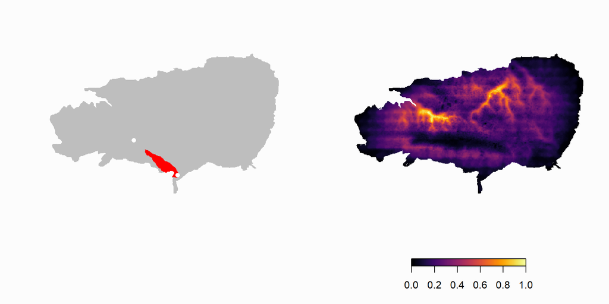

Highest 0.01% values from Cost Corridor (left) and Accumulated Cost Corridors (0.01% highest values) (right)

3. The resultant surface now represents mobility within the landscape. By computing cost corridors between multiple locations when creating the surface, we assumed that movement from each location occured within a wide corridor. Does this assumption agree with all of our initial assumptions? Hopefully your response was **YES!** Our assumption that movement occured within wide corridors remained constant throughout the modelling process.

## Reflections on Modelling Movement Potential

As discussed above, if we are not aware of how alternating between the concepts of mobility and movement can change our assumptions, we can end the modelling process with our results not reflecting nor incorporating the initial assumptions.

## References

Beaudry, Mary Carolyn, and Travis G. Parno, eds. 2013. *Archaeologies of Mobility and Movement*. Contributions to Global Historical Archaeology. New York: Springer.

Bender, Barbara. 2001. “Landscapes on-the-Move.” *Journal of Social Archaeology* 1 (1): 75–89. https://doi.org/10.1177/146960530100100106.

Close, Angela E. 2000. “Reconstructing Movement in Prehistory.” *Journal of Archaeological Method and Theory* 7 (1): 49–77. www.jstor.org/stable/20177412.

Ingold, Tim. 2004. “Culture on the Ground: The World Perceived Through the Feet.” *Journal of Material Culture* 9 (3): 315–40. https://doi.org/10.1177/1359183504046896.

Leary, Jim, ed. 2014. *Past Mobilities: Archaeological Approaches to Movement and Mobility*. Farnham: Ashgate.

Lelièvre, Michelle A, and Maureen E Marshall. 2015. “‘Because Life It Selfe Is but Motion’: Toward an Anthropology of Mobility.” *Anthropological Theory* 15 (4): 434–71. https://doi.org/10.1177/1463499615605221.

Sheets-Johnstone, Maxine. 2011. *The Primacy of Movement*. Expanded 2nd ed. Advances in Consciousness Research (AiCR), v. 82. Amsterdam ; Philadelphia: John Benjamins Pub. Co.

Tilley, Christopher Y. 1994. *A Phenomenology of Landscape: Places, Paths, and Monuments*. Explorations in Anthropology. Oxford, UK ; Providence, R.I: Berg.

White, Devin A., and Sarah B. Barber. 2012. “Geospatial Modeling of Pedestrian Transportation Networks: A Case Study from Precolumbian Oaxaca, Mexico.” *Journal of Archaeological Science* 39 (8): 2684–96. https://doi.org/10.1016/j.jas.2012.04.017.